# HÁBITOS DE SUEÑO DE LOS ESTUDIANTES DE LA UTEC Y SU RELACIÓN CON EL RENDIMIENTO ACADÉMICO

**Tema:** Hábitos de sueño de los estudiantes de la UTEC y su relación con el rendimiento académico.

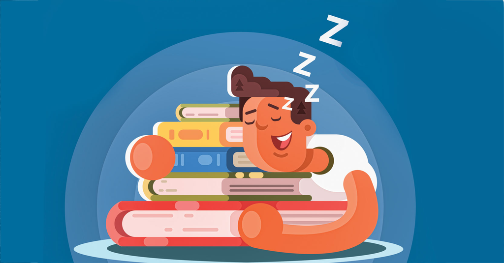

# 1 **Relevancia del estudio:**

El descanso es un aspecto primordial en la vida de cualquier persona, y aún más para los estudiantes universitarios. La evidencia científica respalda la importancia de dormir lo suficiente, ya que permite llevar a cabo las actividades diarias de manera eficiente, controlar el estrés y la ansiedad, y fortalecer el sistema inmunológico. Sin embargo, muchos estudiantes descuidan su descanso debido a la creencia errónea de que no afecta su rendimiento académico. En realidad, la falta de sueño puede tener graves consecuencias en su desempeño académico. Por lo tanto, es crucial abordar este tema y examinar cuántos estudiantes son conscientes de la importancia de su bienestar y cómo la falta de descanso puede perjudicar su rendimiento académico.

## 1.1 *Objetivos:*

1. Evaluar la prevalencia de los problemas de sueño en los estudiantes de la UTEC.
2. Analizar si la cantidad de cursos que lleva un estudiante influye en las horas de sueño.
3. Generar información sobre las preferencias y hábitos de descanso de los estudiantes de UTEC con el fin de promover la mejora de estos espacios.

## 1.2 *Contexto:*

La creciente preocupación por la salud y el bienestar de los estudiantes universitarios ha destacado la importancia del sueño para el éxito académico. El sueño desempeña un papel crucial en el funcionamiento cognitivo, la concentración, la memoria y el estado de ánimo, factores clave en el rendimiento académico. Al analizar los hábitos de sueño de los estudiantes de la UTEC, se obtiene información valiosa sobre la duración, calidad y patrones de sueño, así como posibles interrupciones. Esto brinda una comprensión más profunda de cómo estos factores se relacionan con el rendimiento académico de los estudiantes. La investigación en esta área proporciona datos esenciales para desarrollar estrategias y programas de intervención que fomenten hábitos de sueño saludables entre los estudiantes universitarios. Al promover un mejor sueño, se mejora el bienestar general de los estudiantes y se potencia su éxito académico. Además, esta información puede ser utilizada por las instituciones educativas para implementar políticas y servicios que respalden un sueño adecuado y maximicen el rendimiento académico de los estudiantes.

# 2 **Limpieza de base de datos**

## 2.1 *Cargar los datos*

Para cargar los datos utilizamos la librería ‘readxl’. Asimismo llamamos a la librería ‘dplyr’, para cambiar los nombres de las variables.

```r
library(ggplot2)
library(readr)
library(readxl)
library(dplyr)
library(dplyr)
library(stringr)
```

*Cargamos la base de datos y la asignamos a la tabla DF*

```r
DF<-read_csv("baselimpia.csv")
```

*Nombre de las variables presentes*

```r
names(DF)
```

# 3 **Variable ‘Espacios_de_descanso’**

Analizaremos la variable “Espacios_de_descanso” ya que forma parte de nuestro tercer objetivo, por lo que esta es de suma importancia en la investigación.

```r
moda_espaciosdescanso <- names(table(DF$Espacios_de_descanso))[which.max(table(DF$Espacios_de_descanso))]
moda_espaciosdescanso
```

```r
espacios <- c("Piso 11", "Piso 6", "No hay", "Biblioteca", "Comedor", "Salones vacíos", "Piso 1")
espacio_freq <- colSums(DF[, c("Piso11", "Piso6", "NoEspacio", "Biblioteca", "Comedor", "SalonVacio", "Piso1")])
par(mar = c(5, 10, 4, 2) + 0.1)
barplot(espacio_freq, main = "Lugares que los estudiantes consideran espacios de descanso", xlab = "Espacio de Descanso",cex.axis=0.8, ylab = "Frecuencia", col=rainbow(7), cex.names = 0.7, ylim=c(0,200), cex.main=0.8)
```

[output not shown]

# 4 **Probabilidad empírica**

## 4.1 *Cant.Cursos*

La probabilidad empírica de un evento viene definida por el número de veces que aparece ese evento con respecto al total de casos observados.

1. Calcular cuántos valores distintos hay en la base de datos, de esa forma hallaremos el Espacio Muestral.

```r
DF$Cant.Cursos
```

```r
filter(DF,Cant.Cursos == 3)
filter(DF,Cant.Cursos == 4)
filter(DF,Cant.Cursos == 5)
filter(DF,Cant.Cursos == 6)
filter(DF,Cant.Cursos == 7)
filter(DF,Cant.Cursos == 8)
```

De nuestra base de 227 registros para la variable Cant.Cursos los valores que toma son los siguientes:

Valor 3: 14 veces Valor 4: 15 veces Valor 5: 52 veces Valor 6: 99 veces Valor 7: 41 veces Valor 8: 6 veces

2.Definimos los eventos: - ¿Cuál es la probabilidad de obtener al azar un alumno que lleva 5 cursos de una muestra de 227 alumnos?

3. La probabilidad de cada evento atómico se calcula de la siguiente manera:

Probabilidad del valor 3: 14/227 = 0.06 Probabilidad del valor 4: 15/227 = 0.07 Probabilidad del valor 5: 52/227 = 0.23 Probabilidad del valor 6: 99/227 = 0.44 Probabilidad del valor 7: 41/227 = 0.18 Probabilidad del valor 8: 6/227= 0.03

Estas probabilidades representan la proporción de registros en la base de datos que corresponden a cada valor específico en la columna “Cant.Cursos”.

Conclusión:

- El 6% de 227 alumnos llevan 3 cursos.
- El 7% de 227 alumnos llevan 4 cursos.
- El 23% de 227 alumnos llevan 5 cursos.
- El 44% de 227 alumnos llevan 6 cursos.
- El 18% de 227 alumnos llevan 7 cursos.
- El 3% de 227 alumnos llevan 8 cursos.

## 4.2 *H.Sueño*

1. Calcular cuántos valores distintos hay en la base de datos, de esa forma hallaremos el Espacio muestral

```r
DF$H.Sueño
```

```r
filter(DF,H.Sueño== 8.00)
filter(DF,H.Sueño == 5.30)
filter(DF,H.Sueño == 6.00)
filter(DF,H.Sueño == 6.30)
filter(DF,H.Sueño == 7.00)
filter(DF,H.Sueño== 4.30)
filter(DF,H.Sueño== 5.00)
filter(DF,H.Sueño == 7.30)
filter(DF,H.Sueño == 4.00)
filter(DF,H.Sueño== 2.30)
filter(DF,H.Sueño == 4.60)
filter(DF,H.Sueño== 7.15)
filter(DF,H.Sueño== 8.30)
filter(DF,H.Sueño == 6.10)
filter(DF,H.Sueño == 5.20)
filter(DF,H.Sueño == 3.00)
filter(DF,H.Sueño == 3.20)
filter(DF,H.Sueño== 10.00)
filter(DF,H.Sueño== 6.50)
filter(DF,H.Sueño == 2.00)
filter(DF,H.Sueño == 6.45)
filter(DF,H.Sueño == 9.00)
filter(DF,H.Sueño == 7.45)
filter(DF,H.Sueño== 15.00)
filter(DF,H.Sueño == 7.40)
filter(DF,H.Sueño== 5.45)
```

Agrupamos en intervalos:

```r
nointervalos <- 5   # Número de intervalos que se desea
amplitud <- 2.00 #valor mínimo
rangointervalos <- amplitud / nointervalos
rangointervalos
```

Agrupamos cada valor en intervalos para ello usamos paste:

```r
print(paste("Los valores de cada grupos van ..."," de ", rangointervalos, " en  ", rangointervalos, " a partir de :", min(DF$H.Sueño)))
```

Tabla de frecuencia de los datos agrupados:

```r
tabla.intervalos <- transform(table(cut(DF$H.Sueño, breaks = 5)))
tabla.intervalos
```

```r
plot(tabla.intervalos, main = "H.sueño en intervalos")
```

[output not shown]

De nuestra base de 227 registros para la variable H.Sueño los valores que toma en intervalos son los siguientes:

Valor [1.99, 3.6]: 5 veces Valor [3.6, 5.2]: 56 veces Valor [5.2, 6.8]: 77 veces Valor [6.8, 8.4]: 82 veces Valor [8.4, 10]: 6 veces

2. La función de probabilidad para cada valor se calcula de la siguiente manera:

Probabilidad del valor [1.99, 3.6]: 5/227 = 0.02 Probabilidad del valor [3.6, 5.2]: 56/227 = 0.25 Probabilidad del valor [5.2, 6.8]: 77/227 = 0.34 Probabilidad del valor [6.8, 8.4]: 82/227 = 0.36 Probabilidad del valor [8.4, 10]: 6/227 = 0,03

Conclusiones: - La probabilidad de seleccionar un estudiante al azar que duerma entre 1.99 a 3.6 horas en una muestra de 227 es de 2%. - La probabilidad de seleccionar un estudiante al azar que duerma entre 3.6 a 5.2 horas en una muestra de 227 es de 25% - La probabilidad de seleccionar un estudiante al azar que duerma entre 5.2 a 6.8 horas en una muestra de 227 es de 34%. - La probabilidad de seleccionar un estudiante al azar que duerma entre 6.8 a 8.4 horas en una muestra de 227 es de 36%. - La probabilidad de seleccionar un estudiante al azar que duerma entre 8.4 a 10 horas en una muestra de 227 es de 3%.

# 5 **Probabilidad condicional**

## 5.1 *Evento Independiente*

Utilizamos la variable Horas de sueño y horas de estudio siendo ambas continuas.

```r
# Filtrar los valores no faltantes (NA)
DF_filtered <- na.omit(DF)

# Calcular la correlación entre las variables filtradas
correlation <- cor(DF_filtered$H.Sueño, DF_filtered$Horas.de.estudio)
print(correlation)
```

```r
ggplot(DF,aes(x=DF$H.Sueño,y=DF$Horas.de.estudio)) +
  geom_point(shape=1) +
  labs(title="Gráfico 1: Comparación entre horas de sueño y horas de estudio",x="Horas de sueño",y="Horas de estudio") + theme_light() +
  geom_abline(intercept=0, slope=1, col="red")
```

[output not shown]

Se cuenta la información de

- Evento A: “Estudiante que duerma 4 horas cada día”
- Evento B: “Un estudiante estudia menos de 15 horas semanales”

Teniendo la siguiente información:

- La probabilidad de que un estudiante duerma 4 horas al día es 0.4 (P(A)=0.4)

```r
# La probabilidad que un estudiante duerma 4 horas al día, sobre un promedio de 10 horas. Sería 4/10
dormir4 = 4/10
```

- La probabilidad de que un estudiante estudie 15 horas semanales es 0.6 (P(B)=0.6)

```r
Prob15semanales = 0.6
```

Sabemos que si estos eventos son independientes, entonces P(A∩B) = P(A)*P(B) Entonces, la probabilidad de que duerma 4 horas al día y estudie 15 horas semanales es:

P(A∩B) = P(A)* P(B)

```r
Phorasdormidasyestudiadas = Prob15semanales*dormir4
Phorasdormidasyestudiadas
```

Si calculamos las probabilidades condicionales:

P(A|B) = P(A ∩ B) / P(B) = 0.24 / 0.6 = 0.4.

```r
ProbAtalqueB = Phorasdormidasyestudiadas/Prob15semanales
ProbAtalqueB
```

P(B|A) = P(A ∩ B) / P(A) = 0.24 / 0.4 = 0.6.

```r
ProbBtalqueA = Phorasdormidasyestudiadas/dormir4
ProbBtalqueA
```

En este caso, ambas probabilidades condicionales son iguales a las probabilidades individuales de los eventos A y B, respectivamente. Esto indica que los eventos son independientes. Por lo tanto podemos decir que no importa que tantas horas duermas, no influye en las horas de estudio que repases esa misma semana.

## 5.2 *Evento Dependiente*

Evento A: “El tiempo que te quedaste dormido en clase es mayor a 1 hora”. Evento B: “Las horas que duermes en promedio son menores a 8”.

Tenemos una muestra de 227 datos. - La probabilidad de que se quede dormido en clase por más de una hora, según los datos proporcionados, es de 84/227, lo cual es aproximadamente igual a 0.369.

```r
# Filtramos la cantidad de gente que se quedaron dormidos mas de una hora en clase
(filter(DF,DF$Cant.D.U>1))
# Podemos visualizar que tenemos 84 observaciones, por lo tanto, 84 estudiantes se quedaron dormidos más de una hora en clase.
Estudiantesdormidosmas1hr = 84
Total = 227
Probabilidad = Estudiantesdormidosmas1hr/Total
Probabilidad
```

La probabilidad de dormir 8 horas es de 18/227 (18 veces aparece en la muestra de 227 datos), que es igual a 0.079.

```r
Probdormir8horas  = 18/227
Probdormir8horas
```

La probabilidad de dormir 5.30 horas es de 11/227, que es igual a 0.048

```r
Probdormir5horas  = 11/227
Probdormir5horas
```

La probabilidad de dormir 6 horas es de 45/227, que es igual a 0.198.

```r
Probdormir6horas  = 45/227
Probdormir6horas
```

La probabilidad de dormir 7 horas es de 44/227, que es igual a 0.193.

```r
Probdormir7horas  = 44/227
Probdormir7horas
```

```r
Probdormir4horas  = 4/227
Probdormir4horas
```

La probabilidad de dormir 2.30 horas es de 1/227, que es igual a 0.0044

```r
Probdormir2horas  = 1/227
Probdormir2horas
```

```r
Probb = Probdormir2horas+Probdormir4horas+Probdormir5horas+Probdormir6horas+Probdormir7horas+Probdormir8horas
Probb
```

Para verificar la dependencia de los eventos A y B, debemos calcular la probabilidad conjunta P(A ∩ B) y compararla con el producto de las probabilidades individuales P(A) * P(B).

La probabilidad conjunta P(A ∩ B) se obtiene contando los casos en los que se cumplan ambos eventos. De acuerdo con los valores proporcionados, hay 11 casos en los que se quedaron dormidos en clase por más de una hora y las horas de sueño son menores a 8.

Entonces, P(A ∩ B) = 11/227, que es aproximadamente igual a 0.048.

```r
Probconjunta = 11/227
```

Como P(A ∩ B) ≠ P(A) * P(B), podemos concluir que los eventos A y B son dependientes.

# 6 **Variables discretas**

## 6.1 *Cantidad de cursos*

1. Distribución binomial y de la probabilidad: Analizaremos la variable “cantidad de cursos” en base a la distribución Binomial, para ello, en R utilizaremos la función dbinom.

Para realizar el experimento debemos conocer la probabilidad de cada uno, entonces :

| *Opciones* | < span style=“color:#3 F 7281”>*Probabilidad* | *Unidad* |
| --- | --- | --- |
| *Nivel 1* | 0 | Probabilidad que se escoja 1 curso |
| *Nivel 2* | 0 | Probabilidad que se escoja 2 curso |
| *Nivel 3* | 0.0617 | Probabilidad que se escoja 3 curso |
| *Nivel 4* | 0.0661 | Probabilidad que se escoja 4 curso |
| *Nivel 5* | 0.2291 | Probabilidad que se escoja 5 curso |
| *Nivel 6* | 0.4361 | Probabilidad que se escoja 6 curso |
| *Nivel 7* | 0.1806 | Probabilidad que se escoja 7 curso |
| *Nivel 8* | 0.0264 | Probabilidad que se escoja 8 curso |

Densidad de la cantidad de cursos :

```r
μ <- mean(DF$Cant.Cursos)
σ <- sd(DF$Cant.Cursos)
x2 <- c(8, seq(1,1,length=8),1)
y2 <- c(8, dnorm(seq(1,1,length=8), mean = μ, sd = σ), 1)
curve(dnorm(x, mean = μ, sd = σ), from=0, to=8, ylab="",xlab = "",lwd = 1, main="Cantidad de cursos")
text(x = 7, y = 1, 'P(x < 10)' ,cex = 1)
```

[output not shown]

Sabemos que la moda de la cantidad de cursos que escogieron los alumnos es de 6, entonces para que nuestro estudio no tenga como resultado una probabilidad tan pequeña escogeremos una muestra de de 80 alumnos del total.

CASO I: ¿Cuál es la probabilidad de seleccionar a 80 alumnos y que estos hayan llevado 6 cursos en el ciclo?

```r
# Cálculo de la probabilidad utilizando la distribución binomial

P6 <- dbinom(80 , nrow(DF),  sum(DF$Cant.Cursos == "6")/nrow(DF) )
P6
P6*100
P6
```

```r
n <- 80  # Número de ensayos
p <- P6  # Probabilidad de éxito

valor_esperado <- n * p

# Varianza
varianza <- n * p * (1 - p)

print(valor_esperado)
print(varianza)
```

Análisis Probabilístico:

CASO II:

¿Cuál es la probabilidad de seleccionar a 30 alumnos y que este hayan llevado 7 cursos en el ciclo?

```r
# Cálculo de la probabilidad utilizando la distribución binomial
P7 <- dbinom(30, nrow(DF),  sum(DF$Cant.Cursos == "7")/nrow(DF) )
P7
P7*100
```

Valor esperado (media): E(X) = n * p Varianza: Var(X) = n * p * (1 - p)

```r
n <- 30  # Número de ensayos
p <- P7  # Probabilidad de éxito

valor_esperado <- n * p

# Varianza
varianza <- n * p * (1 - p)

print(valor_esperado)
print(varianza)
```

Respuestas: - La probabilidad de tener a 80 alumnos del total de los datos recogidos, mediante la distribución binomial es de : 0.00204 o 0.20463 %

- La probabilidad de tener 30 alumnos del total de los datos recogidos, mediante la distribución binomial es de : 0.0111 o 1.111 %

## 6.2 *Calidad de sueño*

| *Opciones* | < span style=“color:#3 F 7281”>*Probabilidad* | *Unidad* |
| --- | --- | --- |
| *Nivel 1* | 0.0661 | Probabilidad que se escoja el nivel 1 |
| *Nivel 2* | 0.1630 | Probabilidad que se escoja el nivel 2 |
| *Nivel 3* | 0.4581 | Probabilidad que se escoja el nivel 3 |
| *Nivel 4* | 0.2203 | Probabilidad que se escoja el nivel 4 |
| *Nivel 5* | 0.0925 | Probabilidad que se escoja el nivel 5 |

En este experimento, la muestra consiste en seleccionar únicamente 5 niveles de satisfacción (1, 2, 3, 4, 5), lo que representa un conjunto finito. Por lo tanto, utilizaremos una distribución hipergeométrica para analizar cuán probable es que los encuestados estén más satisfechos que otros en cuanto a la calidad del sueño. La distribución hipergeométrica nos permitirá determinar la probabilidad de obtener una muestra en la que haya un mayor número de encuestados satisfechos en comparación con los demás.

Análisis Probabilístico:

Éxito: Que una persona encuestada tenga 3 como nivel de satisfacción en la categoría de “calidad de sueño”

```r
table(DF$Calidad.de.sueño)
```

M= 104 (cantidad de alumnos que escogieron el nivel 3)

N = 227 (tamaño de la población)

n = 50 (tamaño de la muestra)

k = 104 (éxitos en la población)

x <= 20 (personas de la muestra con 3 de satisfacción )

P(x ≤ 20)

N-M= 227-104 = 123

```r
cat('Probabilidad (phyper(x, M, N − M, n)):', phyper(20,104,123,50),'\n')
cat('Valor esperado (E(X)= n*M/N):', 50*104/227,'\n')
cat('Varianza (V(X) = (n*M/N)(1 − M/N)(N-n)/(N-1)):', (50*(50/227))*(1-(50/227))*(227-50)/(227-1),'\n')
cat('Desviación estándar (D(x)=((n*M/N)(1 − M/N)(N-n)/(N-1))^0.5:', ((50*(50/227))*(1-(50/227))*(227-50)/(227-1))^0.5,'\n')
```

CASO IV: ¿Cuál es la probabilidad de que al agarrar una muestra al azar de 45 personas encuestadas, 5 personas tengan un nivel de satisfacción de 5 en la calidad de sueño, sabiendo que la población es de 227 personas encuestadas?

Distribución Hipergeometrica:

N = 227 (tamaño de la población)

n = 45 (tamaño de la muestra)

k = 21 (éxitos en la población)

Respuestas:

# 7 **Variables continuas**

Trabajaremos con las variables “Promedio” y “horas.de.estudio”:

## 7.1 *Promedio*

Lo primero que haremos es identificar esta variable a través de un histograma:

```r
# Eliminar filas con valores faltantes en la variable "Promedio"
DF_clean <- na.omit(DF$Promedio)

# Cálculo de la mediana y el promedio
median_value <- median(DF_clean)
mean_value <- mean(DF_clean)

# Gráfico de histograma y curva de densidad para la variable "Promedio"
hist(DF_clean, breaks = "FD", probability = TRUE, col = "lightblue", xlab = "Promedio", main = "Distribución de Promedio")
lines(density(DF_clean), col = "red", lwd = 2)

# Agregar mediana y promedio al gráfico
abline(v = median_value, col = "blue", lwd = 2, lty = 2)
abline(v = mean_value, col = "green", lwd = 2, lty = 2)
legend("topright", legend = c(paste0("Mediana = ", median_value), paste0("Promedio = ", mean_value)), col = c("blue", "green"), lwd = 2, lty = 2)
```

[output not shown]

Las líneas verticales de color azul representan la mediana, que es de 14.92, mientras que las líneas verdes representan el promedio, que es de 14.9780844660194. La mediana y el promedio están muy cerca y se encuentran en el centro de la distribución. Esto sugiere que la distribución es simétrica y no hay una gran diferencia entre estos valores. Por lo tanto, tanto la mediana como el promedio son medidas de tendencia central similares y representan el valor central típico de los datos.La considermamos una normal.

Validar la normal

```r
medtd <- mean(DF$Promedio, na.rm = TRUE)
meditd <- median(DF$Promedio, na.rm = TRUE)

print(medtd)
print(meditd)
```

```r
utd <- mean(DF$Promedio, na.rm = TRUE)
desvtd <- sd(DF$Promedio, na.rm = TRUE)
print(utd)
print(desvtd)
```

```r
# Calculamos la varianza
vartd <- var(DF$Promedio, na.rm = TRUE)
print(vartd)
vartd2 <- sum((DF$Promedio - medtd)^2, na.rm = TRUE) / (length(DF$Promedio) - sum(is.na(DF$Promedio)))
print(vartd2)
```

Podemos observar que son prácticamente lo mismo

```r
# Calculamos la varianza
vartd <- var(DF$Promedio, na.rm = TRUE)
print(vartd)

# Calculamos la esperanza
espetd <- mean(DF$Promedio, na.rm = TRUE)
print(espetd)
```

Tal que: X ~ N(14.98, 2.71)

```r
# Parámetros
promedio <- 14.98
desviacion <- 2.71
umbral <- 9

# Cálculo de la probabilidad P(X > 9) utilizando la función de distribución acumulativa (pnorm) y complementando con 1
probabilidad <- 1 - pnorm(umbral, mean = promedio, sd = desviacion)
print(probabilidad)
```

## 7.2 *Horas.de.estudio*

```r
# Eliminar filas con valores faltantes en la variable "Horas.de.estudio"
DF_clean <- na.omit(DF$Horas.de.estudio)

# Cálculo de la mediana y el promedio
median_value <- median(DF_clean)
mean_value <- mean(DF_clean)

# Gráfico de histograma y curva de densidad para la variable "Horas.de.estudio"
hist(DF_clean, breaks = "FD", probability = TRUE, col = "lightblue", xlab = "Horas de estudio", main = "Distribución de Horas de estudio")
lines(density(DF_clean), col = "red", lwd = 2)

abline(v = median_value, col = "blue", lwd = 2, lty = 2)
abline(v = mean_value, col = "green", lwd = 2, lty = 2)
legend("topright", legend = c(paste0("Mediana = ", median_value), paste0("Promedio = ", mean_value)), col = c("blue", "green"), lwd = 2, lty = 2)
```

[output not shown]

Se observa una distribución de las horas de estudio, representada por el histograma y la curva de densidad. La mediana, representada por la línea azul, es de 7.3, mientras que el promedio, representado por la línea verde, es de 8.975. Aunque ambas líneas están cercanas entre sí, no se puede afirmar con certeza que la distribución sea simétrica, ya que los valores no son tan cercanos ni iguales. En este caso, se puede observar una diferencia significativa entre la mediana y el promedio, lo que indica que la distribución está sesgada hacia la derecha. Esto se confirma cuando la mediana es menor que el promedio. Ambas medidas representan el valor central típico de las horas de estudio. Pero, consideraremos la gráfica como una normal, para así poder seguir con los pasos dados para variables continuas.

```r
medtd <- mean(DF$Horas.de.estudio, na.rm = TRUE)
meditd <- median(DF$Horas.de.estudio, na.rm = TRUE)

print(medtd)
print(meditd)
```

```r
utd <- mean(DF$Horas.de.estudio, na.rm = TRUE)
desvtd <- sd(DF$Horas.de.estudio, na.rm = TRUE)
print(utd)
print(desvtd)
```

```r
# Calculamos la varianza
vartd <- var(DF$Horas.de.estudio, na.rm = TRUE)
print(vartd)
vartd2 <- sum((DF$Horas.de.estudio - medtd)^2, na.rm = TRUE) / (length(DF$Horas.de.estudio) - sum(is.na(DF$Horas.de.estudio)))
print(vartd2)
```

```r
# Calculamos la varianza
vartd <- var(DF$Horas.de.estudio, na.rm = TRUE)
print(vartd)

# Calculamos la esperanza
espetd <- mean(DF$Horas.de.estudio, na.rm = TRUE)
print(espetd)
```

Tal que: X ~ N(8.98,40.75)

EJEMPLO: se está llevando a cabo un estudio sobre los hábitos de sueño de los estudiantes y su relación con el rendimiento académico. La universidad busca entender cómo los hábitos de sueño pueden afectar el desempeño estudiantil.

```r
#Utilizando los datos proporcionados, podemos utilizar la distribución normal para calcular la probabilidad. Por ejemplo, si estamos interesados en calcular la probabilidad de que un estudiante duerma más de 10 horas al día, podemos utilizar el siguiente código en R:
promedio <- 8.98
desviacion <- 40.75
umbral <- 10

# Cálculo de la probabilidad P(X > X) utilizando la función de distribución acumulativa (pnorm) y complementando con 1
probabilidad <- 1 - pnorm(umbral, mean = promedio, sd = desviacion)
print(probabilidad)
```

# 8 **Conclusiones**

-Por otro lado, se concluye que las horas que un estudiante le dedica al estudio no tienen influencia en las horas que duerme. Esta conclusión se obtuvo a través del cálculo de probabilidades.

```r
write_csv(DF, "baselimpia.csv")
```